[figure not shown]

**School of Computer Science & Engineering**  
R Programming Project Report

# Used Car Price Prediction Using R Programming

**Domain:** Data Science & Predictive Analytics | **Environment:** R 4.6.2 (`stats`, `MASS`, `rpart`) | **Date:** 2026-11-25

**Student Name:** Gutha Vishnu Vardhan Naidu

**Roll Number:** `20241CSD0073`

**Department / Section:** CSE Data Science

**University:** Presidency University, Bengaluru

500

Car Records

0.9585

Best Test R²

0.4600 L

Best Test RMSE

6.43%

Best Test MAPE

## 1. Abstract

Estimating the fair resale price of a pre-owned automobile is a multivariate regression problem driven by vehicle age, distance driven, brand value, engine capacity, fuel type, transmission, and ownership history. This project implements an end-to-end **Used Car Price Prediction** pipeline in **R** across 500 listings spanning 10 automotive brands. Following data cleaning, median missing-value imputation, and feature engineering, four models are trained and benchmarked on an 80/20 train-test split: **Multiple Linear Regression**, **Stepwise AIC Linear Regression**, **Log-Transformed Linear Regression**, and **Decision Tree Regression (`rpart`)**. The Log-Transformed Linear Regression model achieves the strongest test performance (**R² = 0.9585**, **RMSE = 0.4600 Lakhs**, **MAE = 0.3028 Lakhs**, **MAPE = 6.43%**), capturing exponential resale depreciation far better than additive models.

## 2. Problem Statement & Objectives

- **Problem Statement:** Buyers and sellers in the used car market need an objective, data-driven benchmark to estimate fair resale prices from vehicle attributes.
- **Objectives:**
  1. Clean raw vehicle listing data, handle missing values via median imputation, and engineer `Car_Age`.
  2. Perform Exploratory Data Analysis (EDA) using summary statistics, boxplots, scatter plots, and correlation heatmaps.
  3. Train and compare four regression models in R using an 80/20 train-test split.
  4. Evaluate generalization accuracy using RMSE, MAE, R², and MAPE, and verify model residuals.

## 3. Dataset Description

The dataset (`data/used_cars.csv`) consists of **500 rows** and **12 columns**:

| Feature | Type | Description |
| --- | --- | --- |
| `Car_Name` | Categorical | Brand and model (e.g., Hyundai Creta, Maruti Swift) |
| `Brand` | Factor (10 levels) | Maruti, Hyundai, Honda, Tata, Toyota, Mahindra, Kia, Volkswagen, Ford, Skoda |
| `Year` | Numeric | Manufacture year (2012–2025) |
| `Kilometers_Driven` | Numeric | Total odometer reading (6,451 – 236,370 km) |
| `Fuel_Type` | Factor (3 levels) | Petrol, Diesel, CNG |
| `Transmission` | Factor (2 levels) | Manual, Automatic |
| `Owner_Type` | Factor (3 levels) | First, Second, Third |
| `Mileage_kmpl` | Numeric | Fuel efficiency in km/l (12.90 – 27.90) |
| `Engine_cc` | Numeric | Engine displacement in cc (796 – 2,627) |
| `Power_bhp` | Numeric | Engine peak power in bhp (56.10 – 202.30) |
| `Seats` | Factor (2 levels) | Seating capacity (5 or 7 seats) |
| `Selling_Price_Lakhs` | **Target** | Resale selling price in INR Lakhs (1.45 – 14.32) |

## 4. Methodology

### 4.1 Data Cleaning & Feature Engineering

- **Missing-Value Imputation:** 8 missing values in `Mileage_kmpl` and 6 missing values in `Power_bhp` were imputed with their respective medians (`19.30 kmpl` and `106.40 bhp`).
- **Feature Engineering:** Derived `Car_Age = 2026 - Year` and converted categorical variables into R factors.
- **Train-Test Split:** Partitioned into **400 training rows (80%)** and **100 test rows (20%)** with `set.seed(123)`.

### 4.2 Regression Models Implemented

- **Multiple Linear Regression (`stats::lm`):** Additive baseline using all predictors.
- **Stepwise AIC Regression (`MASS::stepAIC`):** Bidirectional feature selection minimizing Akaike Information Criterion.
- **Log-Transformed Linear Regression:** Fits `log(Selling_Price_Lakhs)` with bias-corrected smearing back-transformation `exp(pred + 0.5 * sigma^2)` to model exponential depreciation.
- **Decision Tree Regressor (`rpart::rpart`):** Non-parametric regression tree (`cp = 0.01`, `maxdepth = 6`).

## 5. Exploratory Data Analysis (EDA)

| Feature | Min | Q1 | Median | Mean | Q3 | Max | SD |
| --- | --- | --- | --- | --- | --- | --- | --- |
| `Year` | 2012.00 | 2017.00 | 2019.00 | 2019.05 | 2021.25 | 2025.00 | 3.08 |
| `Car_Age` | 1.00 | 4.75 | 7.00 | 6.95 | 9.00 | 14.00 | 3.08 |
| `Kilometers_Driven` | 6,451 | 48,420.5 | 71,247.5 | 77,709.5 | 98,980.5 | 236,370 | 39,408.6 |
| `Mileage_kmpl` | 12.90 | 17.88 | 19.30 | 19.61 | 21.22 | 27.90 | 2.67 |
| `Engine_cc` | 796.00 | 1,239.75 | 1,427.50 | 1,451.95 | 1,652.00 | 2,627.00 | 317.10 |
| `Power_bhp` | 56.10 | 91.22 | 106.40 | 109.35 | 122.42 | 202.30 | 25.78 |
| `Selling_Price_Lakhs` | 1.45 | 2.85 | 4.02 | 4.56 | 5.68 | 14.32 | 2.44 |

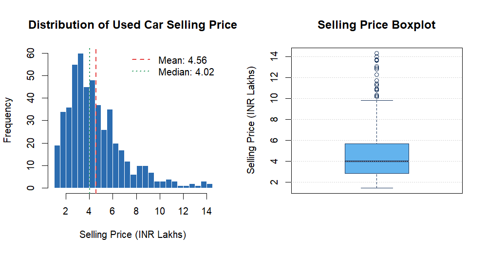

Figure 1: Right-skewed distribution of used car selling prices (Mean = 4.56 L, Median = 4.02 L).

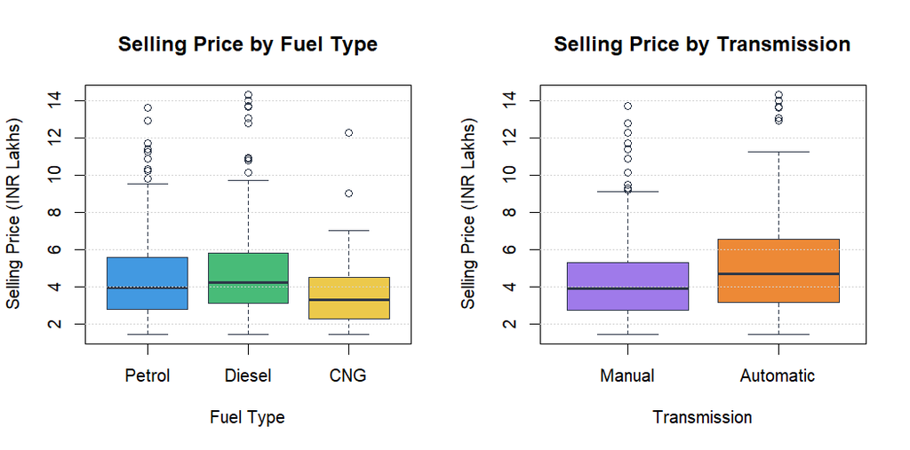

Figure 2: Resale price comparison across Fuel Type and Transmission.

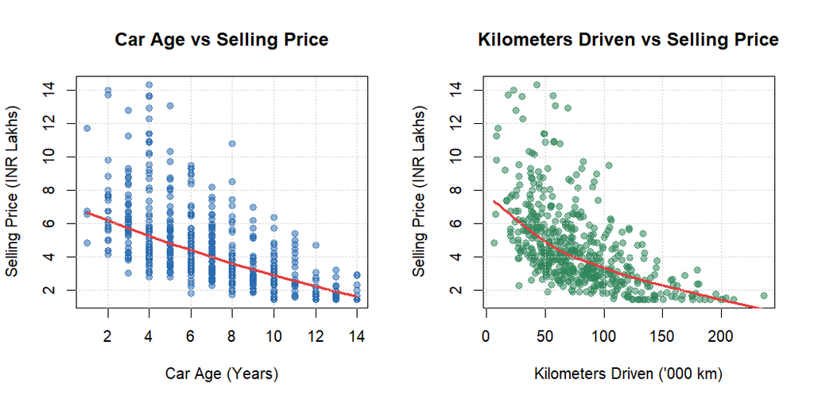

Figure 3: Non-linear price depreciation with Car Age and Kilometers Driven.

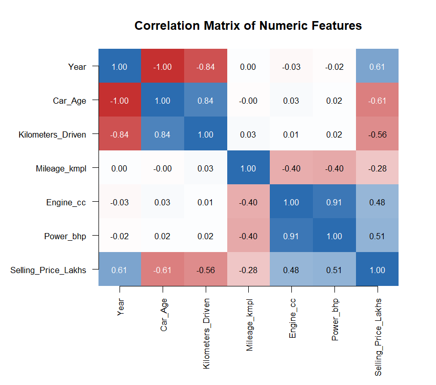

Figure 4: Pearson correlation heatmap across numeric features.

## 6. Model Evaluation & Results

| Rank | Model | RMSE (Lakhs) | MAE (Lakhs) | R² | MAPE (%) |
| --- | --- | --- | --- | --- | --- |
| 1 | Log-Transformed Linear Regression | 0.4600 | 0.3028 | 0.9585 | 6.43% |
| 2 | Multiple Linear Regression | 0.7258 | 0.5230 | 0.8966 | 12.85% |
| 3 | Stepwise Linear Regression (AIC) | 0.7260 | 0.5284 | 0.8966 | 13.00% |
| 4 | Decision Tree (`rpart`) | 1.2410 | 0.9478 | 0.6977 | 21.34% |

On the training set, the Log-Transformed Linear Regression model achieved an **Adjusted R² of 0.9707** and a log-scale Residual Standard Error of **0.089**.

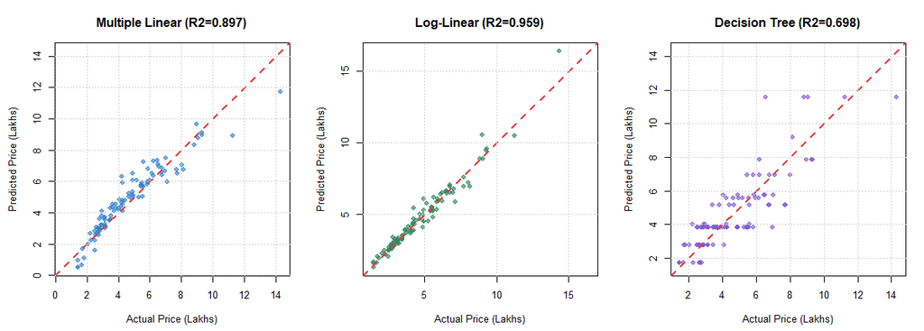

Figure 5: Actual vs Predicted selling prices on the 100-car test set.

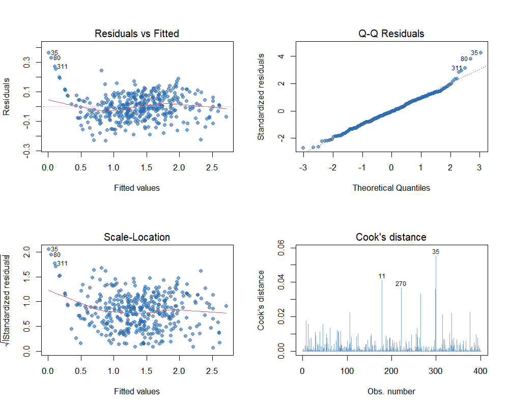

Figure 6: Residual diagnostic plots for the Log-Transformed Linear Regression model.

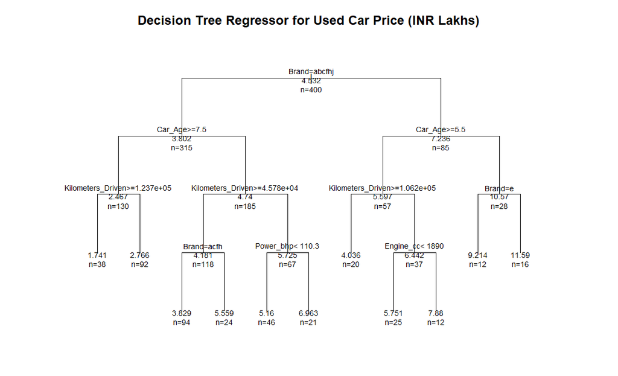

Figure 7: Trained `rpart` Decision Tree structure.

### Sample Test Set Predictions

| Car Name | Year | Fuel | Actual (L) | Log-Linear Pred (L) | Linear Pred (L) |
| --- | --- | --- | --- | --- | --- |
| Ford Endeavour | 2019 | Petrol | 4.91 | 4.52 | 5.12 |
| Tata Altroz | 2021 | CNG | 3.46 | 3.48 | 4.30 |
| Skoda Kushaq | 2022 | CNG | 9.04 | 8.89 | 8.75 |
| Tata Harrier | 2022 | Diesel | 4.25 | 5.41 | 5.90 |
| Ford Figo | 2015 | Diesel | 2.68 | 2.65 | 2.75 |
| Maruti Swift | 2021 | Diesel | 4.91 | 5.28 | 6.05 |
| Maruti Dzire | 2023 | Petrol | 3.81 | 3.90 | 4.29 |
| Skoda Rapid | 2022 | Petrol | 6.55 | 6.45 | 6.96 |
| Volkswagen Polo | 2023 | Petrol | 7.72 | 6.92 | 6.50 |
| Kia Seltos | 2017 | Petrol | 4.04 | 3.68 | 4.28 |

### Predictions on New Unseen Cars

| Brand | Car Age | Fuel Type | Transmission | Kilometers | Predicted Price (Lakhs) |
| --- | --- | --- | --- | --- | --- |
| Hyundai | 4 yrs | Petrol | Automatic | 38,000 km | **6.15** |
| Toyota | 3 yrs | Diesel | Automatic | 45,000 km | **17.86** |
| Maruti | 6 yrs | CNG | Manual | 62,000 km | **2.48** |

## 7. Conclusion & Future Work

Modeling log-transformed used car prices captures multiplicative depreciation across age, mileage, brand, and drivetrain features effectively, reducing test RMSE by **36.6%** (from 0.7258 to 0.4600 Lakhs) and cutting MAPE in half (from 12.85% to 6.43%) relative to standard linear regression. Future enhancements include training Random Forest / Gradient Boosting models and wrapping the predictor in an interactive **R Shiny** dashboard.